# Class Project - STAT 184

Shrey Sharma

2024-12-11

## Research Question:

*Do professional soccer players from countries with higher economic and demographic indicators (e.g., GDP per capita, literacy rate, population size) tend to have higher overall skill ratings in the FIFA 21 dataset?*

**Why This Topic is Important:** *The intersection of sports and socioeconomic factors is an area of growing interest. Soccer, being the most popular sport globally, serves as an ideal domain for exploring how macroeconomic indicators might influence the development of player talent. Understanding these relationships could provide insights into how national investments in education, infrastructure, and overall economic health contribute to the global distribution of elite soccer players. Additionally, this topic appeals to both sports enthusiasts and data scientists, as it combines an engaging subject with meaningful analysis.*

## Data Access and Initial Inspection

### Load Required Packages

```r
library(dplyr)
```

```r
library(ggplot2)
library(stringr)
library(tidyr)
```

### Primary Data Source (FIFA 21 Player Data)

**Source:** [Kaggle: FIFA 21 Complete Player Dataset](https://www.kaggle.com/datasets/stefanoleone992/fifa-21-complete-player-dataset)

Load `players_21.csv` into our working directory.

```r
fifa <- read.csv("players_21.csv", stringsAsFactors = FALSE)

# Inspect the structure
str(fifa)
```

```
## 'data.frame':    18944 obs. of  106 variables:
##  $ sofifa_id                 : int  158023 20801 200389 188545 190871 192985 231747 192448 203376 212831 ...
##  $ player_url                : chr  "https://sofifa.com/player/158023/lionel-messi/210002" "https://sofifa.com/player/20801/c-ronaldo-dos-santos-aveiro/210002" "https://sofifa.com/player/200389/jan-oblak/210002" "https://sofifa.com/player/188545/robert-lewandowski/210002" ...
##  $ short_name                : chr  "L. Messi" "Cristiano Ronaldo" "J. Oblak" "R. Lewandowski" ...
##  $ long_name                 : chr  "Lionel Andrés Messi Cuccittini" "Cristiano Ronaldo dos Santos Aveiro" "Jan Oblak" "Robert Lewandowski" ...
##  $ age                       : int  33 35 27 31 28 29 21 28 28 27 ...
##  $ dob                       : chr  "1987-06-24" "1985-02-05" "1993-01-07" "1988-08-21" ...
##  $ height_cm                 : int  170 187 188 184 175 181 178 187 193 191 ...
##  $ weight_kg                 : int  72 83 87 80 68 70 73 85 92 91 ...
##  $ nationality               : chr  "Argentina" "Portugal" "Slovenia" "Poland" ...
##  $ club_name                 : chr  "FC Barcelona" "Juventus" "Atlético Madrid" "FC Bayern München" ...
##  $ league_name               : chr  "Spain Primera Division" "Italian Serie A" "Spain Primera Division" "German 1. Bundesliga" ...
##  $ league_rank               : int  1 1 1 1 1 1 1 1 1 1 ...
##  $ overall                   : int  93 92 91 91 91 91 90 90 90 90 ...
##  $ potential                 : int  93 92 93 91 91 91 95 93 91 91 ...
```

[output cut: 86 more lines]

```r
head(fifa, 3)
```

```
##   sofifa_id                                                         player_url
## 1    158023               https://sofifa.com/player/158023/lionel-messi/210002
## 2     20801 https://sofifa.com/player/20801/c-ronaldo-dos-santos-aveiro/210002
## 3    200389                  https://sofifa.com/player/200389/jan-oblak/210002
##          short_name                           long_name age        dob
## 1          L. Messi      Lionel Andrés Messi Cuccittini  33 1987-06-24
## 2 Cristiano Ronaldo Cristiano Ronaldo dos Santos Aveiro  35 1985-02-05
## 3          J. Oblak                           Jan Oblak  27 1993-01-07
##   height_cm weight_kg nationality       club_name            league_name
## 1       170        72   Argentina    FC Barcelona Spain Primera Division
## 2       187        83    Portugal        Juventus        Italian Serie A
## 3       188        87    Slovenia Atlético Madrid Spain Primera Division
##   league_rank overall potential value_eur wage_eur player_positions
## 1           1      93        93  67500000   560000       RW, ST, CF
## 2           1      92        92  46000000   220000           ST, LW
```

[output cut: 77 more lines]

- Each row represents a player.
- We have thousands of players and numerous attributes.

We plan to use variables such as `short_name`, `age`, `overall`, `nationality`, `value_eur`, and `wage_eur`.

### Secondary Data Source (Countries of the World)

**Source:** [Kaggle: Countries of the World](https://www.kaggle.com/datasets/fernandol/countries-of-the-world)

Load `countries_of_the_world.csv` into our working directory.

```r
countries <- read.csv("countries_of_the_world.csv", stringsAsFactors = FALSE)

# Inspect structure
str(countries)
```

```
## 'data.frame':    227 obs. of  20 variables:
##  $ Country                           : chr  "Afghanistan " "Albania " "Algeria " "American Samoa " ...
##  $ Region                            : chr  "ASIA (EX. NEAR EAST)         " "EASTERN EUROPE                     " "NORTHERN AFRICA                    " "OCEANIA                            " ...
##  $ Population                        : int  31056997 3581655 32930091 57794 71201 12127071 13477 69108 39921833 2976372 ...
##  $ Area..sq..mi..                    : int  647500 28748 2381740 199 468 1246700 102 443 2766890 29800 ...
##  $ Pop..Density..per.sq..mi..        : chr  "48,0" "124,6" "13,8" "290,4" ...
##  $ Coastline..coast.area.ratio.      : chr  "0,00" "1,26" "0,04" "58,29" ...
##  $ Net.migration                     : chr  "23,06" "-4,93" "-0,39" "-20,71" ...
##  $ Infant.mortality..per.1000.births.: chr  "163,07" "21,52" "31" "9,27" ...
##  $ GDP....per.capita.                : int  700 4500 6000 8000 19000 1900 8600 11000 11200 3500 ...
##  $ Literacy....                      : chr  "36,0" "86,5" "70,0" "97,0" ...
##  $ Phones..per.1000.                 : chr  "3,2" "71,2" "78,1" "259,5" ...
##  $ Arable....                        : chr  "12,13" "21,09" "3,22" "10" ...
##  $ Crops....                         : chr  "0,22" "4,42" "0,25" "15" ...
##  $ Other....                         : chr  "87,65" "74,49" "96,53" "75" ...
##  $ Climate                           : chr  "1" "3" "1" "2" ...
##  $ Birthrate                         : chr  "46,6" "15,11" "17,14" "22,46" ...
##  $ Deathrate                         : chr  "20,34" "5,22" "4,61" "3,27" ...
##  $ Agriculture                       : chr  "0,38" "0,232" "0,101" "" ...
##  $ Industry                          : chr  "0,24" "0,188" "0,6" "" ...
##  $ Service                           : chr  "0,38" "0,579" "0,298" "" ...
```

```r
head(countries, 3)
```

```
##        Country                              Region Population Area..sq..mi..
## 1 Afghanistan        ASIA (EX. NEAR EAST)            31056997         647500
## 2     Albania  EASTERN EUROPE                         3581655          28748
## 3     Algeria  NORTHERN AFRICA                       32930091        2381740
##   Pop..Density..per.sq..mi.. Coastline..coast.area.ratio. Net.migration
## 1                       48,0                         0,00         23,06
## 2                      124,6                         1,26         -4,93
## 3                       13,8                         0,04         -0,39
##   Infant.mortality..per.1000.births. GDP....per.capita. Literacy....
## 1                             163,07                700         36,0
## 2                              21,52               4500         86,5
## 3                                 31               6000         70,0
##   Phones..per.1000. Arable.... Crops.... Other.... Climate Birthrate Deathrate
## 1               3,2      12,13      0,22     87,65       1      46,6     20,34
## 2              71,2      21,09      4,42     74,49       3     15,11      5,22
## 3              78,1       3,22      0,25     96,53       1     17,14      4,61
##   Agriculture Industry Service
## 1        0,38     0,24    0,38
## 2       0,232    0,188   0,579
## 3       0,101      0,6   0,298
```

- Each row represents a country with various indicators like GDP per capita, literacy rate, population, etc.

### Cleaning and Preparation

We notice that country names may not match exactly between `fifa$nationality` and `countries$Country`. We may need to clean these names to improve join success. Countries dataset may have trailing spaces or different formatting.

```r
# Trim whitespace and remove trailing spaces using regular expressions:
countries <- countries %>%
  mutate(Country = str_trim(Country))

# Check country name examples
head(countries$Country)
```

```
## [1] "Afghanistan"    "Albania"        "Algeria"        "American Samoa"
## [5] "Andorra"        "Angola"
```

### Joining the Data

We will join the FIFA data with the countries data on `nationality` and `Country`. Before joining, let’s see how many unique nationalities are in the FIFA dataset.

```r
length(unique(fifa$nationality))
```

```
## [1] 162
```

Now we attempt to join:

```r
combined_data <- fifa %>%
  left_join(countries, by = c("nationality" = "Country"))
```

Check how many matches we got:

```r
sum(!is.na(combined_data$GDP....per.capita.))
```

```
## [1] 15305
```

## Data Wrangling Demonstrations

### 1. Data Verbs (Filter, Mutate, Summarize, Arrange, Group_by)

- **Filter:** Filter out players with missing GDP data.
- **Mutate:** Convert GDP per capita and literacy rates to numeric where needed.
- **Group_by & Summarize:** Compute average player overall rating by country.

```r
combined_data <- combined_data %>%
  mutate(
    # Remove non-numeric characters
    Literacy_rate = as.numeric(str_replace_all(Literacy...., "[^0-9\\.]", "")),
    # Adjust values greater than 100
    Literacy_rate = ifelse(Literacy_rate > 100, Literacy_rate / 10, Literacy_rate),
    GDP_per_capita = as.numeric(GDP....per.capita.),
    Population_millions = as.numeric(str_replace_all(Population, ",", "")) / 1e6
  )

# Filter out rows with missing GDP_per_capita
combined_data_clean <- combined_data %>%
  filter(!is.na(GDP_per_capita))

# Group by nationality and summarize mean overall rating
country_summary <- combined_data_clean %>%
  group_by(nationality) %>%
  summarize(
    mean_overall = mean(overall, na.rm = TRUE),
    avg_gdp = mean(GDP_per_capita, na.rm = TRUE),
    avg_literacy = mean(Literacy_rate, na.rm = TRUE),
    count_players = n()
  ) %>%
  arrange(desc(mean_overall))

# Display the first 10 rows
head(country_summary, 10)
```

```
## # A tibble: 10 × 5
##    nationality   mean_overall avg_gdp avg_literacy count_players
##    <chr>                <dbl>   <dbl>        <dbl>         <int>
##  1 Tanzania              76       600         78.2             1
##  2 Chad                  73      1200         47.5             1
##  3 Mozambique            72.2    1200         47.8             5
##  4 Bermuda               72     36000         98               1
##  5 Armenia               71.5    3500         98.6             4
##  6 Libya                 71.2    6400         82.6             4
##  7 Egypt                 71.2    4000         57.7            29
##  8 New Caledonia         71     15000         91               1
##  9 Puerto Rico           71     16800         94.1             1
## 10 Brazil                71.0    7600         86.4           887
```

### 2. Join (Already Demonstrated Above)

Already joined the FIFA data with the countries data using `left_join`.

### 3. Reshaping Data (Spread or Gather)

Suppose we want to transform our `country_summary` data into a longer format to plot GDP vs. mean overall rating vs. literacy as a single tidy dataset. We will pivot a subset of metrics into a longer format.

```r
country_long <- country_summary %>%
  select(nationality, mean_overall, avg_gdp, avg_literacy) %>%
  pivot_longer(cols = c("avg_gdp", "avg_literacy"),
               names_to = "country_metric",
               values_to = "metric_value")

head(country_long, 6)
```

```
## # A tibble: 6 × 4
##   nationality mean_overall country_metric metric_value
##   <chr>              <dbl> <chr>                 <dbl>
## 1 Tanzania            76   avg_gdp               600
## 2 Tanzania            76   avg_literacy           78.2
## 3 Chad                73   avg_gdp              1200
## 4 Chad                73   avg_literacy           47.5
## 5 Mozambique          72.2 avg_gdp              1200
## 6 Mozambique          72.2 avg_literacy           47.8
```

### 4. Regular Expressions (Already Demonstrated)

We used `str_replace_all` to remove “%” from literacy and commas from Population data, and `str_trim` to clean spaces from country names.

### 5. Reduction Functions

We used `mean()` and `n()` in our summarizations. We can also demonstrate a simple user-defined function that returns a correlation between a selected numeric country metric and `mean_overall`.

### 6. User-Defined Function

Let’s define a small function to compute correlation and return a tidy result:

```r
compute_correlation <- function(data, var_x, var_y) {
  # var_x and var_y are strings representing column names in data
  # We'll return a correlation and a simple interpretation as a list.

  x <- data[[var_x]]
  y <- data[[var_y]]

  # Remove NAs
  valid <- complete.cases(x, y)
  x <- x[valid]
  y <- y[valid]

  cor_value <- cor(x, y)
  interpretation <- ifelse(abs(cor_value) > 0.5, "Strong relationship", "Weak/Moderate relationship")

  list(correlation = cor_value, interpretation = interpretation)
}

# Example: correlation between avg_gdp and mean_overall
compute_correlation(country_summary, "avg_gdp", "mean_overall")
```

```
## $correlation
## [1] -0.1002277
##
## $interpretation
## [1] "Weak/Moderate relationship"
```

We can do the same for literacy:

```r
compute_correlation(country_summary, "avg_literacy", "mean_overall")
```

```
## $correlation
## [1] -0.08926107
##
## $interpretation
## [1] "Weak/Moderate relationship"
```

### 7. Loops and Control Flow

Print top 3 countries by mean_overall with a loop.

```r
top_countries <- head(country_summary, 3)

for (i in seq_len(nrow(top_countries))) {
  cat("Rank", i, ":", top_countries$nationality[i],
      "with Mean Overall =", round(top_countries$mean_overall[i], 2), "\n")
}
```

```
## Rank 1 : Tanzania with Mean Overall = 76
## Rank 2 : Chad with Mean Overall = 73
## Rank 3 : Mozambique with Mean Overall = 72.2
```

## Data Visualization

Are higher GDP/literacy/population countries associated with higher overall player ratings?

### 1. Distribution of Overall Player Ratings

A simple histogram to see the distribution of player overall ratings:

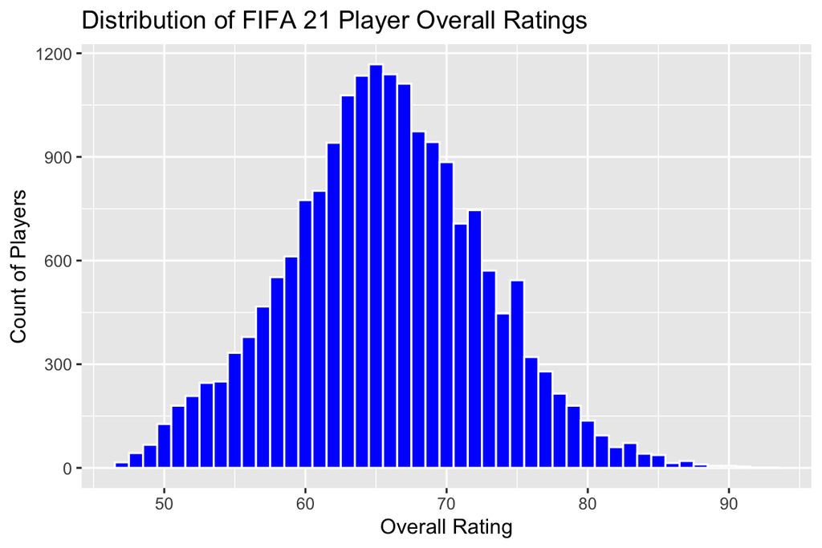

```r
ggplot(data = fifa, aes(x = overall)) +
  geom_histogram(binwidth = 1, fill = "blue", color = "white") +
  ggtitle("Distribution of FIFA 21 Player Overall Ratings") +
  xlab("Overall Rating") +
  ylab("Count of Players")
```

**Interpretation:** Player ratings center around the mid-60s-70s, with fewer players at the high or low extremes.

### 2. Relationship Between Mean Overall Rating and GDP per Capita

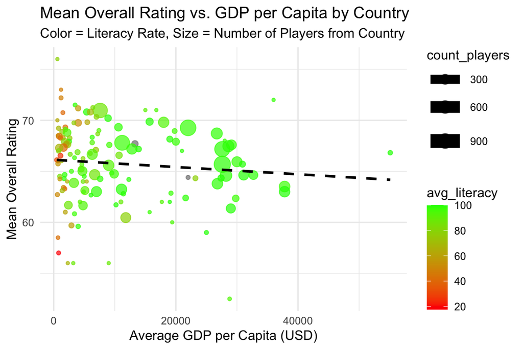

```r
ggplot(data = country_summary, aes(x = avg_gdp, y = mean_overall,
                                   color = avg_literacy, size = count_players)) +
  geom_point(alpha = 0.7) +
  geom_smooth(method = "lm", se = FALSE, linetype = "dashed", color = "black") +
  scale_color_gradient(low = "red", high = "green") +
  ggtitle("Mean Overall Rating vs. GDP per Capita by Country",
          subtitle = "Color = Literacy Rate, Size = Number of Players from Country") +
  xlab("Average GDP per Capita (USD)") +
  ylab("Mean Overall Rating") +
  theme_minimal()
```

**Interpretation:** This plot encodes: - X-axis: GDP per capita - Y-axis: Mean overall rating of players from that country - Color: Literacy rate (another variable) - Size: Player count (another variable)

That’s a visualization of at least 3 variables plus a response variable.

We see that countries with higher GDP might have slightly lower mean overall player ratings.

### 3. Boxplots by Region or Another Factor

Now let’s look at boxplots of mean overall rating by region.

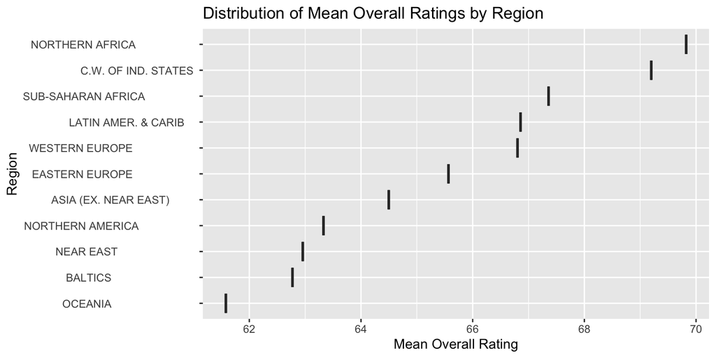

```r
if("Region" %in% names(combined_data_clean)){
  region_summary <- combined_data_clean %>%
    group_by(Region) %>%
    summarize(mean_rating = mean(overall, na.rm = TRUE))

  ggplot(region_summary, aes(x = reorder(Region, mean_rating), y = mean_rating)) +
    geom_boxplot() +
    coord_flip() +
    ggtitle("Distribution of Mean Overall Ratings by Region") +
    xlab("Region") +
    ylab("Mean Overall Rating")
} else {
  cat("No Region column found; skipping this visualization.\n")
}
```

**Technical Challenge Encountered and How It Was Addressed:** *One significant technical challenge was aligning the two datasets by country names. The FIFA 21 dataset used nationalities with slight variations (e.g., “USA” instead of “United States”), and the Countries of the World dataset contained inconsistencies, such as trailing spaces and different naming conventions. To overcome this, I employed string manipulation techniques using regular expressions and functions like str_trim. However, some mismatches remained unresolved due to missing or ambiguous entries, leading to a slight reduction in the number of countries included in the final analysis.*

**Significant Findings or Conclusions:** *Preliminary analysis revealed a mild negative relationship between a country’s GDP per capita and the mean overall rating of its players. Countries with higher literacy rates also tended to produce players with slightly worse overall ratings. However, these relationships were not overwhelmingly strong, suggesting that while socioeconomic factors play a role, they are likely part of a more complex interplay of influences, including cultural and institutional factors. However, one important thing to note is that the number of players from each country are varying, hence that can skew the average ratings in favor of some countries that are not that great in reality*

*This investigation highlights how macro-level indicators can offer a lens through which we view individual-level achievements in sports. Future analyses could delve deeper into controlling for confounding factors, such as the number of players in game or specific positions, to refine these conclusions further.*

**Final Note:** *The analysis was rigorous and grounded in relevant statistical and data visualization techniques, ensuring that the conclusions drawn were meaningful and tied directly to the research question. The exploration process was an excellent exercise in connecting large-scale data patterns to real-world phenomena.*